# Assignment 5 Cynthia Begay

```r
#Distribution is not uniform for pm25; possibly due to small data
```

[output not shown]

[output not shown]

[output cut: 300 more lines]

[output not shown]

```r
table(CHScomb$fev2)
```

[output not shown]

[output cut: 447 more lines]

[output not shown]

```r
table(CHScomb$smoke_gas_exposure)
```

```
##
## Gas & Smoke Exposure    Gas Exposure Only          No Exposure
##                  151                  739                  214
##  Smoke Exposure Only
##                   36
```

```r
table(CHScomb$pm25_mass2)
```

```
##
##  5.96  7.19  7.48  7.66   8.5  8.74 12.35 19.12 20.52 22.39 22.46 29.97
##   100   100   100   100   100   100   100   100   100   100   100   100
```

```r
summary(CHScomb$bmi2)
```

```
##    Min. 1st Qu.  Median    Mean 3rd Qu.    Max.
##   11.30   15.96   17.81   18.50   19.99   41.27
```

```r
summary(CHScomb$fev2)
```

```
##    Min. 1st Qu.  Median    Mean 3rd Qu.    Max.
##   984.8  1827.6  2016.4  2030.1  2223.6  3323.7
```

```r
summary(CHScomb$smoke_gas_exposure)
```

```
##    Length     Class      Mode
##      1200 character character
```

```r
summary(CHScomb$pm25_mass2)
```

```
##    Min. 1st Qu.  Median    Mean 3rd Qu.    Max.
##   5.960   7.615  10.545  14.362  20.988  29.970
```

The key variables seem to have plausible values and ranges.

1. Facet plot showing scatterplots with regression lines of BMI vs FEV by “townname”.

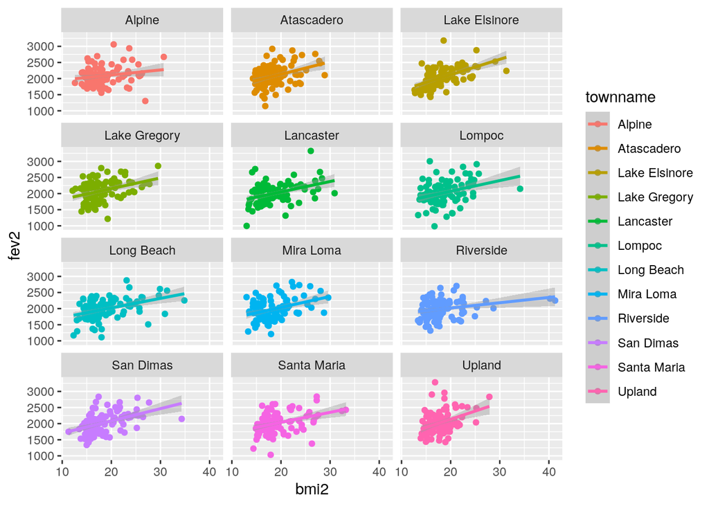

```r
CHScomb %>%
filter(!(townname %in% NA)) %>%
  ggplot(mapping = aes(x=bmi2, y=fev2, color=townname))+
  geom_point()+
  stat_smooth(method=lm)+
   facet_wrap(~townname, nrow=4)
```

2. Stacked histograms of FEV by BMI category and FEV by smoke/gas exposure. Use different color schemes than the ggplot default.

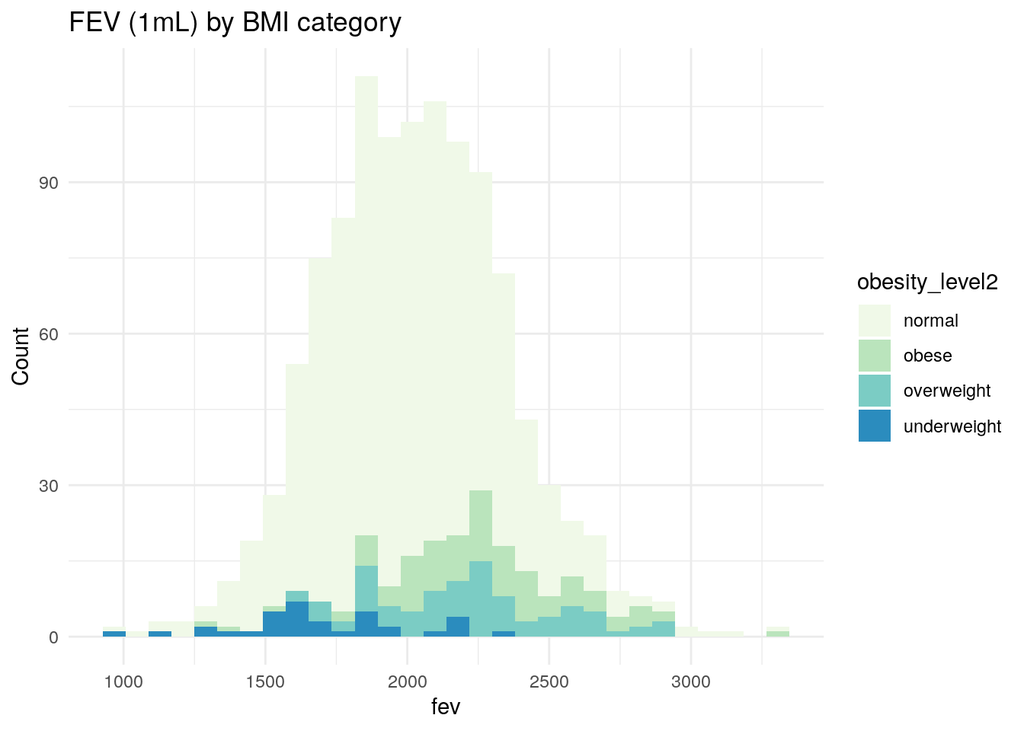

```r
CHScomb %>%
  filter(!(obesity_level2 %in% NA)) %>%
  ggplot()+
  geom_histogram(mapping= aes (x=fev2, fill=obesity_level2))+
  scale_fill_brewer(palette = "GnBu")+
  labs(title="FEV (1mL) by BMI category", x="fev", y="Count")+
  theme_minimal()
```

Those with normal bmi are distributed throughout all fev values, with the highest concentration in the 1800-2200 range. Those with lower bmi are on the lower end of fev; alternatively, those who are overweight have higher fev levels.

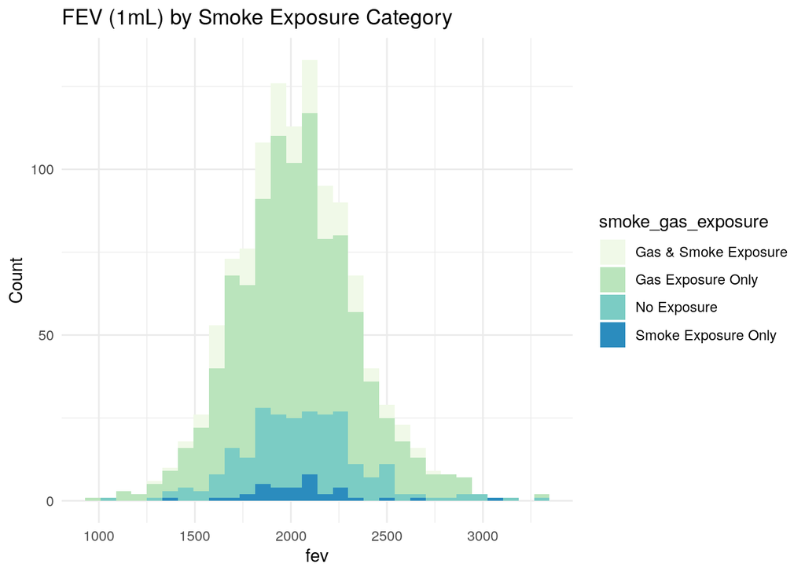

```r
CHScomb %>%
  filter(!(smoke_gas_exposure %in% NA)) %>%
  ggplot()+
  geom_histogram(mapping= aes (x=fev2, fill=smoke_gas_exposure))+
  scale_fill_brewer(palette = "GnBu")+
  labs(title="FEV (1mL) by Smoke Exposure Category", x="fev", y="Count")+
  theme_minimal()
```

All categories of smoke/gas exposure seem to be evenly distributed among all fev values. The highest concentration for all smoke/gas exposure values hovers between 1800 and 2200.

3.Barchart of BMI by smoke/gas exposure.

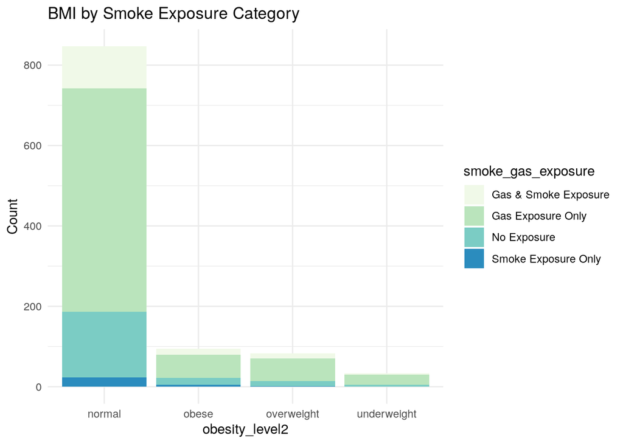

```r
CHScomb %>%
  filter(!(smoke_gas_exposure %in% NA)) %>%
  filter(!(obesity_level2 %in% NA)) %>%
  ggplot()+
  geom_bar(mapping= aes (x=obesity_level2, fill=smoke_gas_exposure))+
  scale_fill_brewer(palette = "GnBu")+
  labs(title="BMI by Smoke Exposure Category", x="obesity_level2", y="Count")+
  theme_minimal()
```

4. Statistical summary graphs of FEV by BMI and FEV by smoke/gas exposure category.

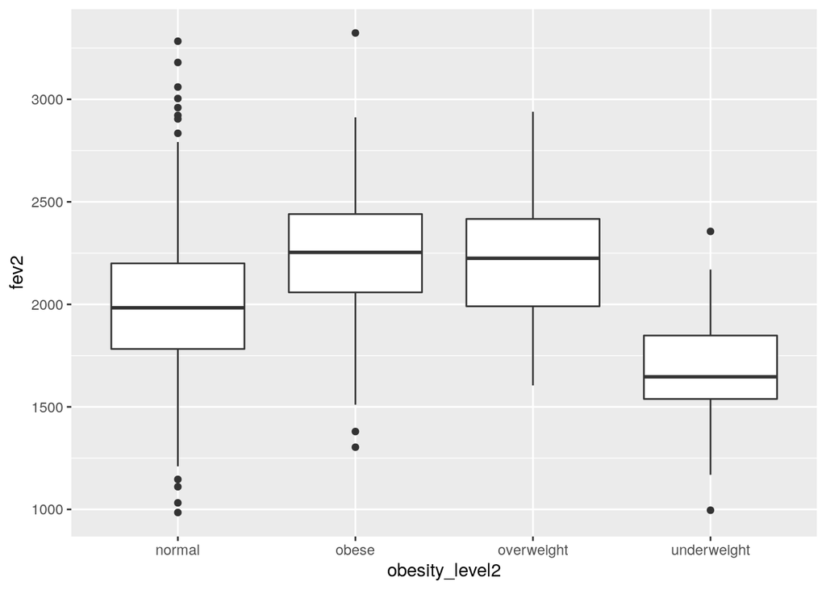

```r
#Boxplot FEV vs Obesity Levels
CHScomb %>%
  filter(!(obesity_level2 %in% NA)) %>%
ggplot()+
  geom_boxplot(mapping = aes(y=fev2, x=obesity_level2))
```

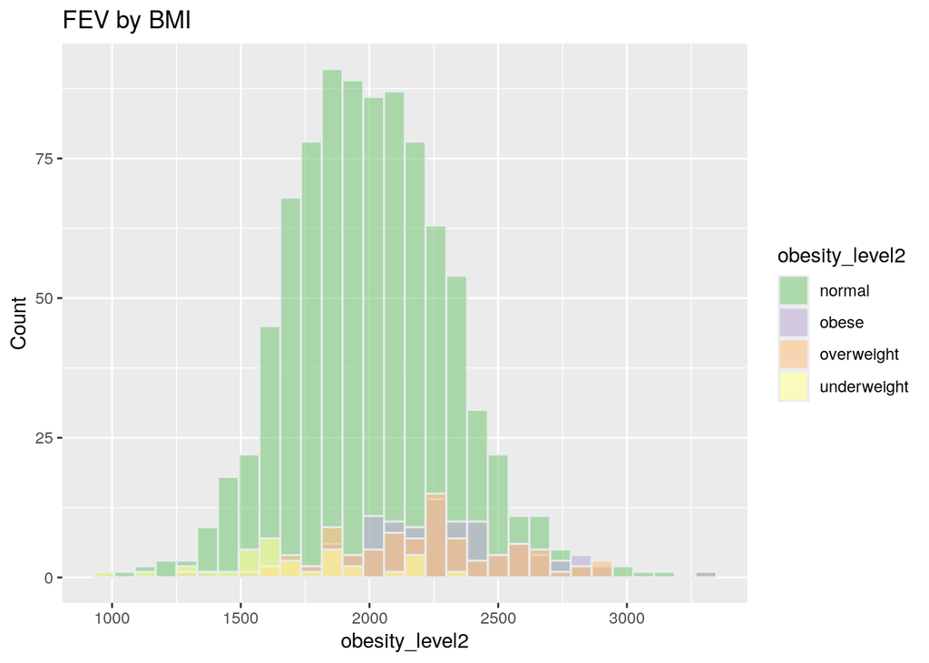

```r
#Histogram FEV vs Obesity Levels
CHScomb %>%
  filter(!(obesity_level2 %in% NA)) %>%
  ggplot( aes(x=fev2, fill=obesity_level2)) +
    geom_histogram( color="#e9ecef", alpha=0.6, position = 'identity') +
    scale_fill_brewer(palette = "Accent")+
   labs(title="FEV by BMI", x="obesity_level2", y="Count")
```

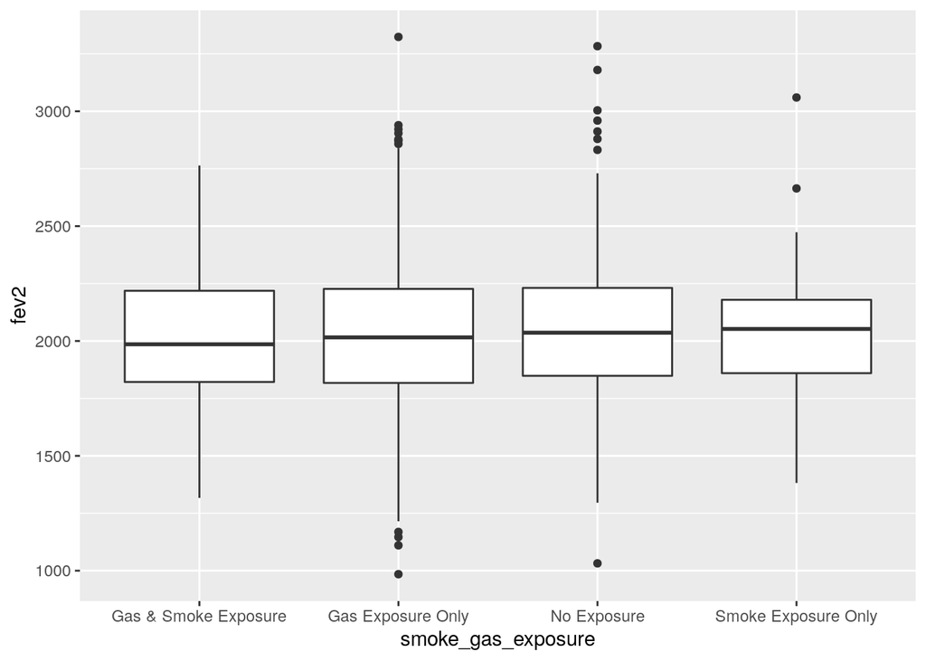

```r
#Boxplot FEV by Exposure

CHScomb %>%
  filter(!(smoke_gas_exposure %in% NA)) %>%
ggplot()+
  geom_boxplot(mapping = aes(y=fev2, x=smoke_gas_exposure))
```

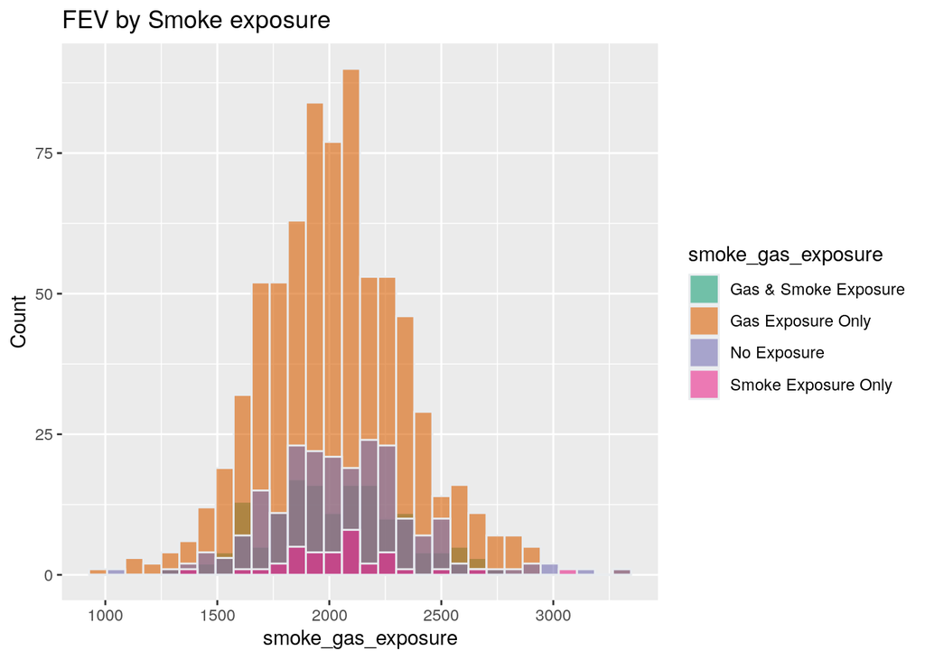

```r
#Histogram FEV vs Exposure
CHScomb %>%
  filter(!(smoke_gas_exposure %in% NA)) %>%
  ggplot( aes(x=fev2, fill=smoke_gas_exposure)) +
    geom_histogram( color="#e9ecef", alpha=0.6, position = 'identity') +
    scale_fill_brewer(palette = "Dark2")+
   labs(title="FEV by Smoke exposure", x="smoke_gas_exposure", y="Count")
```

5. A leaflet map showing the concentrations of PM2.5 mass in each of the CHS communities.

There are higher pm 2.5 mass concentrations in the Los Angeles, Riverside, and San Bernardino areas.

```r
CHScomb <-CHScomb[!is.na(pm25_mass)]

pm25_mass_pal = colorNumeric(c('blue', 'purple', 'red'), domain=CHScomb$pm25_mass)

leaflet(CHScomb) %>%
  addProviderTiles('OpenStreetMap') %>%
  addCircles(lat=~lat, lng=~lon, color=~pm25_mass_pal(pm25_mass), opacity=1, fillOpacity = 1, radius=500) %>%
  addLegend('bottomleft', pal=pm25_mass_pal, values=CHScomb$pm25_mass, title="PM 2.5 Mass Map", opacity=1)
```

[interactive chart not shown]

6. Choose a visualization to examine whether PM2.5 mass is associated with FEV.

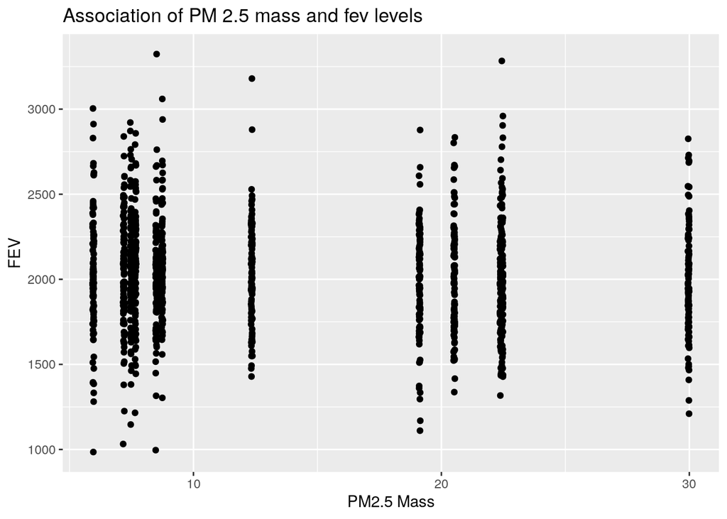

```r
CHScomb %>%
  ggplot(mapping = aes(x=pm25_mass, y=fev2))+
  geom_jitter()+
labs(title="Association of PM 2.5 mass and fev levels", x="PM2.5 Mass", y="FEV")
```

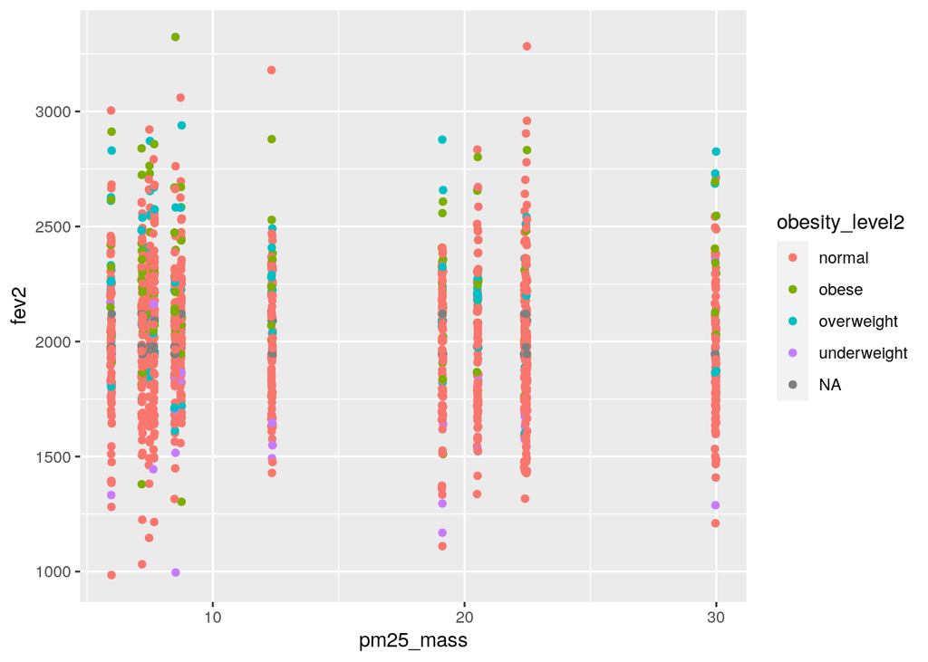

```r
p <- ggplot(CHScomb, aes(pm25_mass, fev2))
p + geom_jitter(aes(color=obesity_level2))
```

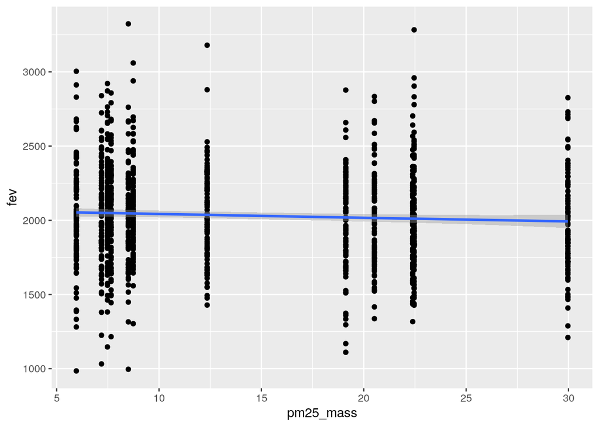

```r
CHScomb %>%
  filter(!(pm25_mass %in% NA)) %>%
  ggplot(mapping = aes(x = pm25_mass,y = fev))+
  geom_point()+
  geom_smooth()
```